# Reproducible Research: Peer Assesment 1

*Submitted by: Sanjib Tiwari*  
*Date: 11/22/2019*

# Activity Monitoring Data Analysis

The activity monitoring data was obtained from coursera course web site

The different variables in the dataset are

- steps: Number of steps taken in 5 minute interval. Contains missing values
- date: Measurement Date
- interval: The interval at which readings were taken

```r
# loading required libraries
library(tidyverse) # for data manupulation/wrangling
library(ggplot2) # for vizualization
library(lubridate) # for working with dates
```

The following code reads the data and converts the date (Make sure you have set up your working directory correctly)

```r
activity <- read.csv("activity.csv")
activity$date <- ymd(activity$date)
```

Taking a look at the data

```r
glimpse(activity)
```

```
## Observations: 17,568
## Variables: 3
## $ steps    <int> NA, NA, NA, NA, NA, NA, NA, NA, NA, NA, NA, NA, NA, N...
## $ date     <date> 2012-10-01, 2012-10-01, 2012-10-01, 2012-10-01, 2012...
## $ interval <int> 0, 5, 10, 15, 20, 25, 30, 35, 40, 45, 50, 55, 100, 10...
```

## Part A Analysis: What is mean total number of steps taken per day?

```r
steps_stat_per_day <- activity %>%
  select(date, steps) %>%
  group_by(date) %>%
  summarize(total_steps  = sum(steps, na.rm = TRUE),
            mean_steps   = mean(x = total_steps, na.rm = TRUE),
            median_steps = median(total_steps, na.rm = TRUE)) %>%
  ungroup(.)
```

The following code displays the mean and median number of steps taken per day

```r
str_glue("The mean number of steps taken per day is {round(mean(steps_stat_per_day$total_steps, na.rm =TRUE),2)}")
```

```
## The mean number of steps taken per day is 9354.23
```

```r
str_glue("The median number of steps taken per day is {round(median(steps_stat_per_day$total_steps, na.rm =TRUE),2)}")
```

```
## The median number of steps taken per day is 10395
```

Histogramm of the total number of steps taken each day

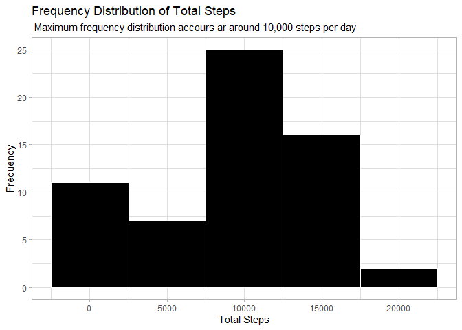

```r
steps_stat_per_day %>%

  ggplot(aes(total_steps)) +

  geom_histogram(binwidth = 5000, color = "white", fill = "black") +

  labs( title = "Frequency Distribution of Total Steps",
        subtitle = " Maximum frequency distribution accours ar around 10,000 steps per day",
        x = "Total Steps",
        y = "Frequency") +
  theme_light()
```

## Part B Analysis: What is the average daily activity pattern?

Data manupulation

```r
interval_mean_steps <- activity %>%
  select(steps, interval) %>%
  group_by(interval) %>%
  summarize(mean_steps = mean(steps, na.rm = TRUE)) %>%
  ungroup(.)
```

Time Series plot

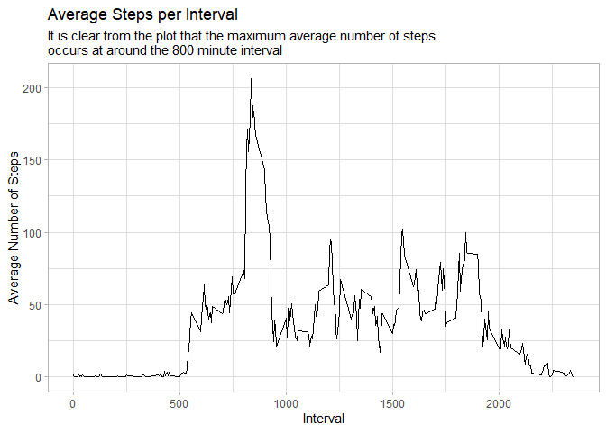

```r
interval_mean_steps %>%
  ggplot(aes(interval,mean_steps)) +

  geom_line() +

  labs(title = "Average Steps per Interval",
       subtitle = "It is clear from the plot that the maximum average number of steps
occurs at around the 800 minute interval",
       x = "Interval",
       y = "Average Number of Steps") +

   theme_light()
```